# Connectome-Based Predictive Modelling of Cognitive Performance in Psychiatric Disorders

Leong Rui Ying Clarisse | NTU Singapore | HP4210 BrainHack School 2026

2026-06-29

# 1. Background & Motivation

This project investigates whether resting-state functional connectivity (rsFC) can **transdiagnostically** predict individual cognitive performance across schizophrenia (SZ), bipolar disorder (BD), ADHD, and healthy controls using **Connectome-Based Predictive Modelling (CPM)** (Shen et al., 2017).

Schizophrenia, bipolar disorder, and ADHD share overlapping cognitive impairment profiles — including deficits in working memory, verbal memory, attention, processing speed, and inhibitory control — yet differ in severity rather than which domains are affected (Vöhringer et al., 2013). If these shared deficits arise from common alterations in functional brain organisation, a single rsFC-based model should predict cognitive performance across diagnostic boundaries. This is the **transdiagnostic hypothesis** tested here.

**Data sources:**

- **Resting-state fMRI timeseries**: Bryant et al. (2023), publicly available on Zenodo (DOI: 10.5281/zenodo.10431855). Preprocessed rsfMRI timeseries from the UCLA Consortium for Neuropsychiatric Phenomics (CNP) LA5c Study (ds000030), using fMRIPrep v1.1.1 with ICA-AROMA (non-aggressive) + 2P + global mean regression denoising. Timeseries extracted from 82 brain regions: 68 cortical (Desikan-Killiany atlas) + 14 subcortical, 152 timepoints per subject.
- **Behavioural and demographic data**: Publicly available on OpenNeuro (ds000030; Poldrack et al., 2016; DOI: 10.18112/openneuro.ds000030.v1.0.0).

# 2. Setup

```r
library(tidyverse)
library(R.matlab)
library(corrplot)
library(ggplot2)
library(patchwork)
library(RColorBrewer)
library(scales)
library(psych)
```

# 3. Load & Prepare Data

## 3.1 Load rsfMRI Timeseries

The Zenodo `.mat` file stores all subjects’ timeseries in a flat matrix. Each subject contributes 82 rows (one per brain region) × 152 columns (timepoints). We identify unique subjects and regions, then reshape into a per-subject list.

```r
mat_data  <- readMat("data/UCLA_CNP_fMRI_TS.mat")
ts_struct <- mat_data$feather.to.mat.struct

subject_ids    <- ts_struct[[1]][, 1]
brain_regions  <- trimws(ts_struct[[2]][, 1])
timeseries_mat <- ts_struct[[3]]

unique_subjects <- unique(subject_ids)
unique_regions  <- unique(brain_regions)

cat("Total rows:",            length(subject_ids),    "\n")
```

```
## Total rows: 21320
```

```r
cat("Unique subjects:",       length(unique_subjects), "\n")
```

```
## Unique subjects: 260
```

```r
cat("Unique brain regions:",  length(unique_regions),  "\n")
```

```
## Unique brain regions: 82
```

```r
cat("Timepoints per region:", ncol(timeseries_mat),    "\n")
```

```
## Timepoints per region: 152
```

## 3.2 Build Per-Subject Timeseries Arrays

Each subject’s rows are extracted and stored as a **regions × timepoints** matrix.

```r
n_subjects   <- length(unique_subjects)
n_regions    <- length(unique_regions)
n_timepoints <- ncol(timeseries_mat)

ts_list <- vector("list", n_subjects)
names(ts_list) <- unique_subjects

for (i in seq_along(unique_subjects)) {
  subj <- unique_subjects[i]
  idx  <- which(subject_ids == subj)
  ts_list[[subj]] <- timeseries_mat[idx, ]  # regions × timepoints
}

cat("Timeseries list built for", length(ts_list), "subjects\n")
```

```
## Timeseries list built for 260 subjects
```

```r
cat("Each subject matrix:", nrow(ts_list[[1]]), "regions ×",
    ncol(ts_list[[1]]), "timepoints\n")
```

```
## Each subject matrix: 82 regions × 152 timepoints
```

## 3.3 Compute Functional Connectivity Matrices

For each subject, **Pearson correlation** is computed between every pair of regional timeseries to produce an 82×82 FC matrix. The **Fisher-Z transform** (`atanh`) is then applied to normalise the distribution of r-values — raw Pearson r is bounded [−1, 1] with a skewed sampling distribution, whereas Fisher-Z is approximately normally distributed, as required by the linear models in CPM. The diagonal is set to 0. The upper triangle (3,321 unique edges) is flattened into a feature vector per subject.

```r
compute_fc <- function(ts_matrix) {
  fc   <- cor(t(ts_matrix), method = "pearson")
  fc_z <- atanh(fc)  # Fisher-Z transform
  diag(fc_z) <- 0
  return(fc_z)
}

fc_list <- lapply(ts_list, compute_fc)

# Flatten upper triangle → feature vector per subject
n_edges   <- n_regions * (n_regions - 1) / 2
upper_idx <- which(upper.tri(matrix(0, n_regions, n_regions)))

fc_matrix <- matrix(NA, nrow = n_subjects, ncol = n_edges)
rownames(fc_matrix) <- unique_subjects

for (i in seq_along(unique_subjects)) {
  subj <- unique_subjects[i]
  fc_matrix[i, ] <- fc_list[[subj]][upper_idx]
}

cat("FC matrix:", nrow(fc_matrix), "subjects ×", ncol(fc_matrix), "edges\n")
```

```
## FC matrix: 260 subjects × 3321 edges
```

## 3.4 Load Behavioural Data

Five cognitive domains are assessed using validated neuropsychological tasks:

| Domain | Task | Variable | Scoring direction |
| --- | --- | --- | --- |
| Working memory | WAIS Letter-Number Sequencing | `lns_totalraw` | Higher = better |
| Attention | CPT False Alarms | `cpt_fa` | **Lower = better** (fewer errors) |
| Verbal memory | CVLT Total Correct | `cvlt_totcor` | Higher = better |
| Processing speed | Color Trails Time 1 | `crt_time1` | **Lower = better** (faster) |
| Inhibitory control | SSRT | `sst_ses_ssrt` | **Lower = better** (faster stop) |

Note that attention, processing speed, and inhibitory control are error or latency measures — higher values indicate worse performance. This is important for interpreting the sign of CPM prediction accuracy.

```r
participants <- read_tsv("data/phenotype/participants.tsv",  show_col_types = FALSE)
wais         <- read_tsv("data/phenotype/wais.tsv",         show_col_types = FALSE)
cpt          <- read_tsv("data/phenotype/cpt.tsv",          show_col_types = FALSE)
cvlt         <- read_tsv("data/phenotype/cvlt.tsv",         show_col_types = FALSE)
colortrails  <- read_tsv("data/phenotype/colortrails.tsv",  show_col_types = FALSE)
stopsignal   <- read_tsv("data/phenotype/stopsignal.tsv",   show_col_types = FALSE)

beh <- participants %>%
  select(participant_id, diagnosis, age, gender) %>%
  left_join(wais        %>% select(participant_id, wm            = lns_totalraw),  by = "participant_id") %>%
  left_join(cpt         %>% select(participant_id, attention     = cpt_fa),         by = "participant_id") %>%
  left_join(cvlt        %>% select(participant_id, verbal_memory = cvlt_totcor),   by = "participant_id") %>%
  left_join(colortrails %>% select(participant_id, proc_speed    = crt_time1),     by = "participant_id") %>%
  left_join(stopsignal  %>% select(participant_id, inhibition    = sst_ses_ssrt),  by = "participant_id") %>%
  mutate(
    inhibition     = as.numeric(inhibition),
    participant_id = gsub("sub-", "", participant_id)
  )

cat("Behavioural data rows:", nrow(beh), "\n")
```

```
## Behavioural data rows: 272
```

```r
cat("Diagnosis breakdown:\n")
```

```
## Diagnosis breakdown:
```

```r
print(table(beh$diagnosis))
```

```
##
##    ADHD BIPOLAR CONTROL    SCHZ
##      43      49     130      50
```

## 3.5 Match FC and Behavioural Data

```r
fc_subj_clean <- gsub("sub-", "", rownames(fc_matrix))
matched_idx   <- match(fc_subj_clean, beh$participant_id)
valid         <- !is.na(matched_idx)

fc_matched  <- fc_matrix[valid, ]
beh_matched <- beh[matched_idx[valid], ]

cat("Matched N =", nrow(fc_matched), "\n")
```

```
## Matched N = 260
```

```r
cat("Diagnosis breakdown (matched):\n")
```

```
## Diagnosis breakdown (matched):
```

```r
print(table(beh_matched$diagnosis))
```

```
##
##    ADHD BIPOLAR CONTROL    SCHZ
##      40      49     121      50
```

# 4. Residualise Cognitive Scores

Cognitive scores are **residualised against age and gender** using linear regression before CPM. The residuals represent each participant’s cognitive performance after removing variance attributable to demographic differences between groups, ensuring CPM captures genuine brain-behaviour relationships rather than demographic confounds.

**Why this matters:** The diagnostic groups in UCLA CNP differ systematically in age and gender composition. Without correction, CPM may predict diagnosis-related demographic variation rather than FC-cognition relationships. Working memory and attention showed apparently significant predictions before covariate correction (r ≈ −0.19, p = 0.003) that disappeared after — confirming these were demographic confounds, not genuine neural signal.

```r
residualise <- function(score, age, gender) {
  df          <- data.frame(score = score, age = age, gender = gender)
  df_complete <- df[!is.na(score), ]
  model       <- lm(score ~ age + gender, data = df_complete)
  resid_full  <- rep(NA, nrow(df))
  resid_full[!is.na(score)] <- residuals(model)
  return(resid_full)
}

beh_matched <- beh_matched %>%
  mutate(
    wm_resid        = residualise(wm,           age, gender),
    attention_resid = residualise(attention,     age, gender),
    vm_resid        = residualise(verbal_memory, age, gender),
    ps_resid        = residualise(proc_speed,    age, gender),
    inhib_resid     = residualise(inhibition,    age, gender)
  )

cat("Residualised scores computed\n")
```

```
## Residualised scores computed
```

# 5. Connectome-Based Predictive Modelling (CPM)

## 5.1 Method Overview

CPM (Shen et al., 2017) predicts individual cognitive scores from whole-brain FC using **leave-one-out cross-validation (LOO-CV)**:

1. **Hold out** one participant as the test case
2. **Correlate** each of the 3,321 FC edges with the cognitive score across the remaining N−1 training participants
3. **Select edges** significantly correlated at p < 0.01 — separately for positive edges (higher FC → higher score) and negative edges (higher FC → lower score)
4. **Compute network strength**: `net_strength = Σ(positive edges) − Σ(negative edges)`
5. **Fit a linear model**: cognitive score ~ net_strength (training data only)
6. **Predict** the held-out participant’s score using their net_strength
7. **Repeat** for all N participants; compute **Pearson r** between all predicted and observed scores as the accuracy metric

**Why p < 0.01?** Standard threshold from Shen et al. (2017), balancing edge selection sensitivity against overfitting — too liberal includes noise, too strict leaves too few edges to build a reliable network.

**Why LOO-CV?** With N ≈ 260, LOO-CV maximises training data at each fold and is standard practice for CPM at this sample size.

## 5.2 CPM Function

```r
run_cpm <- function(fc_mat, scores, p_thresh = 0.01) {

  valid_idx  <- which(!is.na(scores))
  fc_use     <- fc_mat[valid_idx, ]
  scores_use <- scores[valid_idx]
  N          <- length(scores_use)
  predicted  <- rep(NA, N)

  for (i in 1:N) {
    if (i %% 20 == 0) cat("  LOO iteration", i, "/", N, "\n")

    train_fc     <- fc_use[-i, ]
    train_scores <- scores_use[-i]
    test_fc      <- fc_use[i, ]

    edge_cors <- apply(train_fc, 2, function(edge) {
      ct <- cor.test(edge, train_scores, method = "pearson")
      c(r = ct$estimate, p = ct$p.value)
    })
    r_vals <- edge_cors["r.cor", ]
    p_vals <- edge_cors["p",     ]

    pos_edges <- which(p_vals < p_thresh & r_vals > 0)
    neg_edges <- which(p_vals < p_thresh & r_vals < 0)

    pos_str_train <- if (length(pos_edges) > 0) rowSums(train_fc[, pos_edges, drop = FALSE]) else rep(0, N - 1)
    neg_str_train <- if (length(neg_edges) > 0) rowSums(train_fc[, neg_edges, drop = FALSE]) else rep(0, N - 1)
    net_str_train <- pos_str_train - neg_str_train

    fit <- lm(train_scores ~ net_str_train)

    pos_str_test <- if (length(pos_edges) > 0) sum(test_fc[pos_edges]) else 0
    neg_str_test <- if (length(neg_edges) > 0) sum(test_fc[neg_edges]) else 0
    net_str_test <- pos_str_test - neg_str_test

    predicted[i] <- coef(fit)[1] + coef(fit)[2] * net_str_test
  }

  ct <- cor.test(predicted, scores_use, method = "pearson")
  cat("  r =", round(ct$estimate, 3), "  p =", round(ct$p.value, 4), "\n\n")

  return(list(
    predicted = predicted,
    observed  = scores_use,
    r         = ct$estimate,
    p         = ct$p.value,
    N         = N
  ))
}
```

## 5.3 Run CPM

```r
cat("Running CPM (LOO-CV) — this may take 10–15 mins...\n\n")
```

```
## Running CPM (LOO-CV) — this may take 10–15 mins...
```

```r
cognitive_domains <- list(
  working_memory     = beh_matched$wm_resid,
  attention          = beh_matched$attention_resid,
  verbal_memory      = beh_matched$vm_resid,
  processing_speed   = beh_matched$ps_resid,
  inhibitory_control = beh_matched$inhib_resid
)

cpm_results <- list()
for (domain in names(cognitive_domains)) {
  cat("Running CPM for:", domain, "\n")
  cpm_results[[domain]] <- run_cpm(fc_matched, cognitive_domains[[domain]])
}
```

```
## Running CPM for: working_memory
##   LOO iteration 20 / 260
##   LOO iteration 40 / 260
##   LOO iteration 60 / 260
##   LOO iteration 80 / 260
##   LOO iteration 100 / 260
##   LOO iteration 120 / 260
##   LOO iteration 140 / 260
##   LOO iteration 160 / 260
##   LOO iteration 180 / 260
##   LOO iteration 200 / 260
##   LOO iteration 220 / 260
##   LOO iteration 240 / 260
##   LOO iteration 260 / 260
##   r = 0.027   p = 0.6677
##
## Running CPM for: attention
##   LOO iteration 20 / 260
##   LOO iteration 40 / 260
##   LOO iteration 60 / 260
##   LOO iteration 80 / 260
##   LOO iteration 100 / 260
##   LOO iteration 120 / 260
##   LOO iteration 140 / 260
##   LOO iteration 160 / 260
##   LOO iteration 180 / 260
##   LOO iteration 200 / 260
##   LOO iteration 220 / 260
##   LOO iteration 240 / 260
##   LOO iteration 260 / 260
##   r = 0.076   p = 0.2275
##
## Running CPM for: verbal_memory
##   LOO iteration 20 / 260
##   LOO iteration 40 / 260
##   LOO iteration 60 / 260
##   LOO iteration 80 / 260
##   LOO iteration 100 / 260
##   LOO iteration 120 / 260
##   LOO iteration 140 / 260
```

[output cut: 23 more lines]

```
##
## Running CPM for: inhibitory_control
##   LOO iteration 20 / 258
##   LOO iteration 40 / 258
##   LOO iteration 60 / 258
##   LOO iteration 80 / 258
##   LOO iteration 100 / 258
##   LOO iteration 120 / 258
##   LOO iteration 140 / 258
##   LOO iteration 160 / 258
##   LOO iteration 180 / 258
##   LOO iteration 200 / 258
##   LOO iteration 220 / 258
##   LOO iteration 240 / 258
##   r = 0.139   p = 0.0279
```

# 6. Results

```r
results_df <- map_dfr(names(cpm_results), function(domain) {
  res <- cpm_results[[domain]]
  tibble(
    `Cognitive Domain` = domain,
    N                  = res$N,
    r                  = round(res$r, 3),
    p                  = round(res$p, 3),
    Significant        = ifelse(res$p < 0.05, "✓", "")
  )
})

knitr::kable(results_df,
             caption = "CPM Prediction Accuracy per Cognitive Domain (after age + gender covariate correction)")
```

CPM Prediction Accuracy per Cognitive Domain (after age + gender covariate correction)

| Cognitive Domain | N | r | p | Significant |
| --- | --- | --- | --- | --- |
| working_memory | 260 | 0.027 | 0.668 |  |
| attention | 260 | 0.076 | 0.228 |  |
| verbal_memory | 260 | 0.149 | 0.017 | ✓ |
| processing_speed | 260 | 0.056 | 0.377 |  |
| inhibitory_control | 258 | 0.139 | 0.028 | ✓ |

**Interpretation:**

- **Verbal memory** (r = 0.149, p = 0.017) and **inhibitory control** (r = 0.139, p = 0.028) are significantly predicted by resting-state FC across all four diagnostic groups. Both survive covariate correction, indicating genuine brain-behaviour relationships rather than demographic confounds.
- **Working memory and attention** were significant before covariate correction (r ≈ −0.19, p = 0.003 each) but lost significance after — their apparent FC-cognition link was driven by age and gender differences between groups, not genuine neural signal.
- **Processing speed** was non-significant before and after correction. Resting-state FC may not capture the neural substrates of processing speed; task-evoked FC during a speed task would be more appropriate.
- The bar chart below uses **|r| (absolute r)** to compare prediction magnitude across domains regardless of scale direction — some tasks score higher = worse (e.g. SSRT, CPT false alarms), making the sign of r task-dependent rather than biologically meaningful. Signed r and p-values are in the table above.

# 7. Visualisations

## 7.1 Predicted vs Observed Scatter Plots

Each panel shows CPM-predicted scores (y-axis) against residualised observed scores (x-axis), coloured by diagnosis group. A significant positive trend indicates the model has captured genuine FC-cognition signal beyond what age and gender explain.

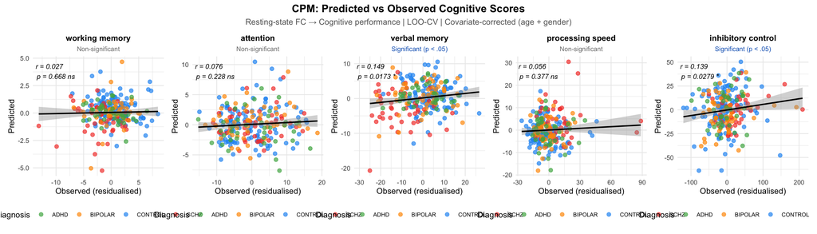

```r
diag_colors <- c("CONTROL" = "#2196F3", "SCHZ" = "#F44336",
                 "BIPOLAR" = "#FF9800", "ADHD"  = "#4CAF50")

plot_list <- list()
for (nm in names(cpm_results)) {
  res        <- cpm_results[[nm]]
  valid_rows <- which(!is.na(cognitive_domains[[nm]]))
  df <- data.frame(
    observed  = res$observed,
    predicted = res$predicted,
    diagnosis = beh_matched$diagnosis[valid_rows]
  )

  sig_label <- if (res$p < 0.05) "*" else "ns"
  label     <- paste0("r = ", round(res$r, 3),
                      "\np = ", format.pval(res$p, digits = 3), " ", sig_label)

  p <- ggplot(df, aes(x = observed, y = predicted, colour = diagnosis)) +
    geom_point(alpha = 0.7, size = 2) +
    geom_smooth(method = "lm", colour = "black", se = TRUE, linewidth = 0.8) +
    scale_colour_manual(values = diag_colors) +
    annotate("text", x = -Inf, y = Inf, label = label,
             hjust = -0.1, vjust = 1.5, size = 3, fontface = "italic") +
    labs(title    = gsub("_", " ", nm),
         subtitle = ifelse(res$p < 0.05, "Significant (p < .05)", "Non-significant"),
         x = "Observed (residualised)", y = "Predicted",
         colour = "Diagnosis") +
    theme_minimal(base_size = 10) +
    theme(plot.title    = element_text(hjust = 0.5, face = "bold", size = 10),
          plot.subtitle = element_text(hjust = 0.5, size = 8,
                                       colour = ifelse(res$p < 0.05, "#1565C0", "gray50")),
          legend.position = "bottom",
          legend.text = element_text(size = 7))
  plot_list[[nm]] <- p
}

wrap_plots(plot_list, ncol = 5) +
  plot_annotation(
    title    = "CPM: Predicted vs Observed Cognitive Scores",
    subtitle = "Resting-state FC → Cognitive performance | LOO-CV | Covariate-corrected (age + gender)",
    theme    = theme(plot.title    = element_text(size = 13, face = "bold", hjust = 0.5),
                     plot.subtitle = element_text(size = 10, hjust = 0.5, colour = "gray40"))
  )
```

## 7.2 CPM Prediction Accuracy Summary

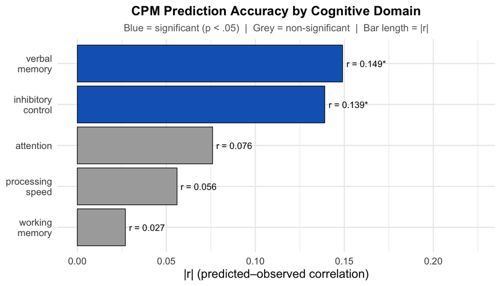

```r
results_df %>%
  mutate(
    domain   = gsub("_", "\n", `Cognitive Domain`),
    fill_col = ifelse(p < 0.05, "#1565C0", "#AAAAAA"),
    label    = ifelse(p < 0.05, paste0("r = ", r, "*"), paste0("r = ", r))
  ) %>%
  ggplot(aes(x = reorder(domain, abs(r)), y = abs(r), fill = fill_col)) +
  geom_col(colour = "black", linewidth = 0.3) +
  geom_text(aes(label = label), hjust = -0.1, size = 3.2) +
  scale_fill_identity() +
  coord_flip() +
  ylim(0, max(abs(results_df$r)) * 1.5) +
  labs(
    title    = "CPM Prediction Accuracy by Cognitive Domain",
    subtitle = "Blue = significant (p < .05)  |  Grey = non-significant  |  Bar length = |r|",
    x = NULL,
    y = "|r| (predicted–observed correlation)"
  ) +
  theme_minimal(base_size = 12) +
  theme(plot.title    = element_text(face = "bold", size = 13, hjust = 0.5),
        plot.subtitle = element_text(size = 10, hjust = 0.5, colour = "gray40"))
```

## 7.3 Example FC Matrix

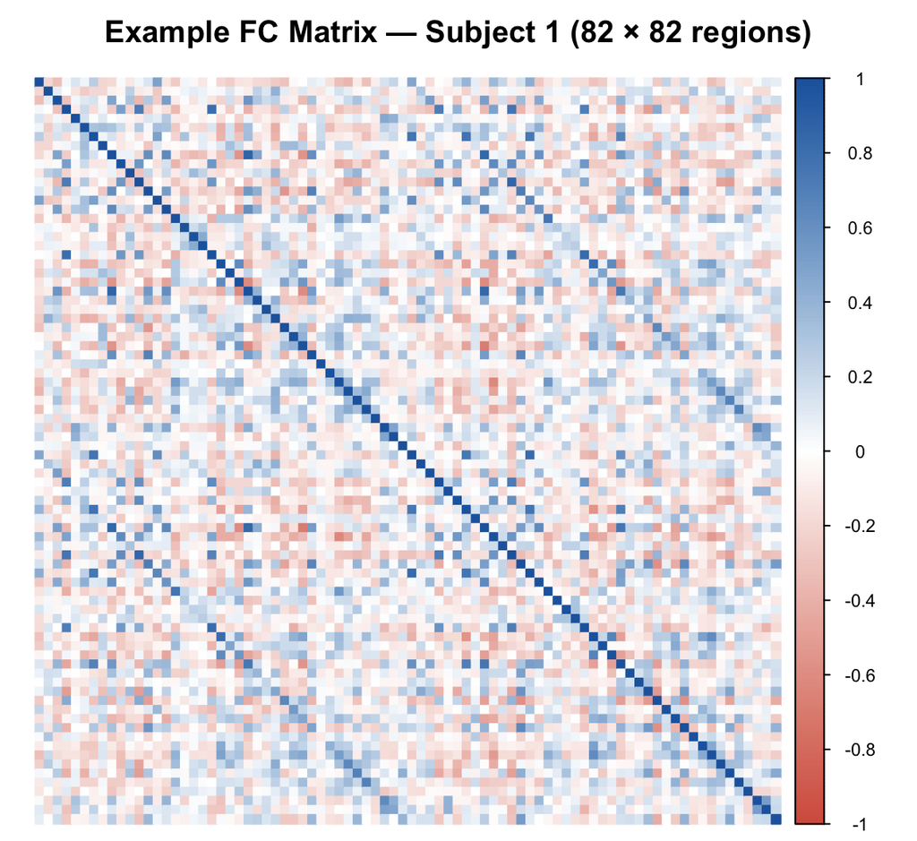

```r
example_fc <- cor(t(ts_list[[1]]), method = "pearson")
rownames(example_fc) <- unique_regions
colnames(example_fc) <- unique_regions

corrplot(example_fc,
         method = "color",
         type   = "full",
         tl.pos = "n",
         cl.cex = 0.7,
         col    = colorRampPalette(c("#D6604D", "white", "#2166AC"))(200),
         title  = "Example FC Matrix — Subject 1 (82 × 82 regions)",
         mar    = c(0, 0, 2, 0))
```

# 8. Save Results

```r
# CPM summary table
write.csv(results_df, "CPM_summary.csv", row.names = FALSE)

# Scatter plots
scatter_save <- {
  pl <- list()
  for (nm in names(cpm_results)) {
    res        <- cpm_results[[nm]]
    valid_rows <- which(!is.na(cognitive_domains[[nm]]))
    df <- data.frame(observed  = res$observed, predicted = res$predicted,
                     diagnosis = beh_matched$diagnosis[valid_rows])
    label <- paste0("r = ", round(res$r, 3), ", p = ", round(res$p, 3))
    pl[[nm]] <- ggplot(df, aes(x = observed, y = predicted, colour = diagnosis)) +
      geom_point(alpha = 0.6, size = 1.8) +
      geom_smooth(method = "lm", colour = "black", se = TRUE, linewidth = 0.8) +
      scale_colour_manual(values = diag_colors) +
      annotate("text", x = -Inf, y = Inf, label = label,
               hjust = -0.1, vjust = 1.5, size = 2.8, fontface = "italic") +
      labs(title = gsub("_", " ", nm), x = "Observed", y = "Predicted", colour = "Diagnosis") +
      theme_minimal(base_size = 9) +
      theme(plot.title = element_text(hjust = 0.5, face = "bold", size = 9),
            legend.position = "bottom", legend.text = element_text(size = 7))
  }
  wrap_plots(pl, ncol = 5)
}
ggsave("CPM_scatter_plots.png", scatter_save, width = 16, height = 4, dpi = 150)

# Bar plot
bar_save <- results_df %>%
  mutate(domain   = gsub("_", "\n", `Cognitive Domain`),
         fill_col = ifelse(p < 0.05, "#1565C0", "#AAAAAA"),
         label    = ifelse(p < 0.05, paste0("r=", r, "*"), paste0("r=", r))) %>%
  ggplot(aes(x = reorder(domain, abs(r)), y = abs(r), fill = fill_col)) +
  geom_col(colour = "black", linewidth = 0.3) +
  geom_text(aes(label = label), hjust = -0.1, size = 3.2) +
  scale_fill_identity() + coord_flip() +
  ylim(0, max(abs(results_df$r)) * 1.5) +
  labs(title = "CPM Prediction Accuracy", subtitle = "Blue = p < .05",
       x = NULL, y = "|r|") +
  theme_minimal(base_size = 11)
ggsave("CPM_bar_plot.png", bar_save, width = 7, height = 4, dpi = 150)

cat("Saved:\n  CPM_summary.csv\n  CPM_scatter_plots.png\n  CPM_bar_plot.png\n")
```

```
## Saved:
##   CPM_summary.csv
##   CPM_scatter_plots.png
##   CPM_bar_plot.png
```

# References

- Bryant, A. G., Aquino, K., Parkes, L., Fornito, A., & Fulcher, B. D. (2023). Data files to support “Extracting interpretable signatures of whole-brain dynamics through systematic comparison”. *Zenodo*. https://doi.org/10.5281/zenodo.10431855
- Poldrack, R. A., et al. (2016). A phenome-wide examination of neural and cognitive function. *Scientific Data*, 3, 160110. https://doi.org/10.1038/sdata.2016.110
- Shen, X., et al. (2017). Using connectome-based predictive modeling to predict individual behavior from brain connectivity. *Nature Protocols*, 12, 506–518. https://doi.org/10.1038/nprot.2016.178
- Vöhringer, P. A., et al. (2013). Cognitive impairment in bipolar disorder and schizophrenia. *Journal of Psychiatric Research*, 47, 166–172.